# Advanced Modelling

Maxi Kellerbauer

November 5th, 2018

# Read the data

We load the daily data of Munich for PM2.5

```r
data("muc_airPol_p2")
```

remove outliers in the data

```r
data <- clean_model_data(muc_airPol_p2, timesIQR = 1.5)
```

We specify a trainings set for crossvalidation

```r
training_set <- get_test_and_training_set(data, sampel_size = 0.75,
                                          random.seed = 220292)
```

We take the GPP model of 3_simple_modelling_and_crossvalidation.R as base model, and want try to beat the predictive performance. For speeding up the computation we only use the GPP model.

```r
spatial.decay = spT.decay(distribution = Gamm(a = 2, b = 1), tuning = 0.25)
scale.transform = "SQRT"
cov.fnc = "exponential"
priors.gpp <- spT.priors(model = "GPP", inv.var.prior = Gamm(a = 2, b = 1),
                         beta.prior = Norm(0, 10^4))
formula = value ~ humi + temp + rainhist + windhist +
  trafficvol + log(sensor_age)
model.gpp.p2 <- fit_sp_model(data = data,
                             formula = formula,
                             model = 'GPP',
                             priors = priors.gpp,
                             cov.fnc = cov.fnc,
                             knots_count = 20,
                             knots_method = 'random',
                             training_set = training_set,
                             scale.transform = scale.transform,
                             spatial.decay = spatial.decay)
```

```
##
##  Output: GPP approximation models
## ---------------------------------------------------------------
##  Sampled: 5000 of 5000, 100.00%.
##  Batch Acceptance Rate (phi): 17.62%
##  Checking Parameters:
##    phi: 0.0008, rho: 0.2710, sig2eps: 0.4482, sig2eta: 11.1851
##    beta[1]: -2.6674   beta[2]: 0.0058   beta[3]: -0.0553   beta[4]: -0.0557   beta[5]: -0.0869   beta[6]: 0.0441   beta[7]: -0.0282
## ---------------------------------------------------------------
## ##
## # nBurn =  1000 . Iterations =  5000 .
## # Acceptance rate: (phi) =  17.62 %
## ##
## ##
## # Elapsed time: 3.65 Sec.
## ##
##
## # Model: GPP
```

```r
pred.gpp.p2 <- predict(model.gpp.p2, data, training_set)
```

```
##
##  Prediction: GPP models
## -------------------------------------------------
##   Sampled: 400 of 4000, 10.00%
## -------------------------------------------------
## -------------------------------------------------
##   Sampled: 800 of 4000, 20.00%
## -------------------------------------------------
## -------------------------------------------------
##   Sampled: 1200 of 4000, 30.00%
## -------------------------------------------------
## -------------------------------------------------
##   Sampled: 1600 of 4000, 40.00%
## -------------------------------------------------
## -------------------------------------------------
##   Sampled: 2000 of 4000, 50.00%
## -------------------------------------------------
## -------------------------------------------------
##   Sampled: 2400 of 4000, 60.00%
## -------------------------------------------------
## -------------------------------------------------
##   Sampled: 2800 of 4000, 70.00%
## -------------------------------------------------
## -------------------------------------------------
##   Sampled: 3200 of 4000, 80.00%
## -------------------------------------------------
## -------------------------------------------------
##   Sampled: 3600 of 4000, 90.00%
## -------------------------------------------------
## -------------------------------------------------
##   Sampled: 4000 of 4000, 100.00%
## -------------------------------------------------
## ##
## # Predicted samples and summary statistics are given.
## # nBurn =  1000 . Iterations =  5000 .
## ##
## ##
## # Elapsed time: 1.9 Sec.
## ##
```

```r
evaluate_prediction(pred.gpp.p2)
```

```
##   RMSE  MAE  BIAS Coverage   R2
## 1 4.22 3.24 -0.46     0.97 0.64
```

```r
# Manipulate the covariables and the fitting range ------------------------
```

# Manipulate the covariables and the fitting range

First we try to manipulate the Covariables. there are a lot of different ways. We will add individual Intercept for each weekday

```r
formula.wdays = value ~ humi + temp + rainhist + windhist +
  trafficvol + log(sensor_age) + stAirPol::weekday(timestamp) - 1
model.gpp.wdays <- fit_sp_model(data = data,
                               formula = formula.wdays,
                               model = 'GPP',
                               priors = priors.gpp,
                               cov.fnc = cov.fnc,
                               knots_count = 4,
                               report = 5,
                               training_set = training_set,
                               scale.transform = scale.transform,
                               spatial.decay = spatial.decay)
```

```
##
##  Output: GPP approximation models
## ---------------------------------------------------------------
##  Sampled: 1000 of 5000, 20.00%.
##  Batch Acceptance Rate (phi): 77.38%
##  Checking Parameters:
##    phi: 1.2690, rho: -0.0029, sig2eps: 0.3408, sig2eta: 0.2382
##    beta[1]: 0.0069   beta[2]: -0.0476   beta[3]: -0.0390   beta[4]: -0.0881   beta[5]: 0.0297   beta[6]: -0.0875   beta[7]: 4.1091   beta[8]: 4.1696   beta[9]: 4.3201   beta[10]: 4.3121   beta[11]: 4.1593   beta[12]: 3.6648   beta[13]: 3.8700
## ---------------------------------------------------------------
## ---------------------------------------------------------------
##  Sampled: 2000 of 5000, 40.00%.
##  Batch Acceptance Rate (phi): 76.84%
##  Checking Parameters:
##    phi: 0.9449, rho: 0.0721, sig2eps: 0.3373, sig2eta: 0.1909
##    beta[1]: 0.0089   beta[2]: -0.0526   beta[3]: -0.0496   beta[4]: -0.0907   beta[5]: 0.0149   beta[6]: -0.1263   beta[7]: 4.1432   beta[8]: 4.3437   beta[9]: 4.3118   beta[10]: 4.4482   beta[11]: 4.4090   beta[12]: 3.8043   beta[13]: 4.0530
## ---------------------------------------------------------------
## ---------------------------------------------------------------
##  Sampled: 3000 of 5000, 60.00%.
##  Batch Acceptance Rate (phi): 77.93%
##  Checking Parameters:
##    phi: 3.7308, rho: -0.0731, sig2eps: 0.3531, sig2eta: 0.2629
##    beta[1]: 0.0080   beta[2]: -0.0392   beta[3]: -0.0599   beta[4]: -0.0903   beta[5]: 0.0416   beta[6]: -0.1163   beta[7]: 4.1157   beta[8]: 4.3618   beta[9]: 4.2390   beta[10]: 4.3852   beta[11]: 4.2861   beta[12]: 3.7440   beta[13]: 3.9575
## ---------------------------------------------------------------
## ---------------------------------------------------------------
##  Sampled: 4000 of 5000, 80.00%.
##  Batch Acceptance Rate (phi): 77.27%
##  Checking Parameters:
##    phi: 1.7327, rho: 0.0532, sig2eps: 0.3279, sig2eta: 0.4533
##    beta[1]: 0.0062   beta[2]: -0.0382   beta[3]: -0.0393   beta[4]: -0.0940   beta[5]: 0.0430   beta[6]: -0.2142   beta[7]: 4.7390   beta[8]: 4.8989   beta[9]: 4.8767   beta[10]: 5.0523   beta[11]: 4.9533   beta[12]: 4.3848   beta[13]: 4.6312
## ---------------------------------------------------------------
## ---------------------------------------------------------------
##  Sampled: 5000 of 5000, 100.00%.
##  Batch Acceptance Rate (phi): 77.50%
##  Checking Parameters:
##    phi: 1.2228, rho: 0.1088, sig2eps: 0.3289, sig2eta: 0.1830
##    beta[1]: 0.0063   beta[2]: -0.0355   beta[3]: -0.0478   beta[4]: -0.0860   beta[5]: 0.1193   beta[6]: -0.0843   beta[7]: 3.9371   beta[8]: 4.1091   beta[9]: 4.1243   beta[10]: 4.2372   beta[11]: 4.1411   beta[12]: 3.4934   beta[13]: 3.8035
## ---------------------------------------------------------------
## ##
## # nBurn =  1000 . Iterations =  5000 .
## # Acceptance rate: (phi) =  77.48 %
## ##
## ##
## # Elapsed time: 4.49 Sec.
## ##
##
## # Model: GPP
```

```r
pred.gpp.wdays <- predict(model.gpp, data, training_set)
```

```
##
##  Prediction: GPP models
## -------------------------------------------------
##   Sampled: 400 of 4000, 10.00%
## -------------------------------------------------
## -------------------------------------------------
##   Sampled: 800 of 4000, 20.00%
## -------------------------------------------------
## -------------------------------------------------
##   Sampled: 1200 of 4000, 30.00%
## -------------------------------------------------
## -------------------------------------------------
##   Sampled: 1600 of 4000, 40.00%
## -------------------------------------------------
## -------------------------------------------------
##   Sampled: 2000 of 4000, 50.00%
## -------------------------------------------------
## -------------------------------------------------
##   Sampled: 2400 of 4000, 60.00%
## -------------------------------------------------
## -------------------------------------------------
##   Sampled: 2800 of 4000, 70.00%
## -------------------------------------------------
## -------------------------------------------------
##   Sampled: 3200 of 4000, 80.00%
## -------------------------------------------------
## -------------------------------------------------
##   Sampled: 3600 of 4000, 90.00%
## -------------------------------------------------
## -------------------------------------------------
##   Sampled: 4000 of 4000, 100.00%
## -------------------------------------------------
## ##
## # Predicted samples and summary statistics are given.
## # nBurn =  1000 . Iterations =  5000 .
## ##
## ##
## # Elapsed time: 1.81 Sec.
## ##
```

```r
summary(model.gpp)
```

```
## -----------------------------------------------------
## Model: GPP
## Call: value ~ humi + temp + rainhist + windhist + trafficvol + log(sensor_age)
## Iterations: 5000
## nBurn: 1000
## Acceptance rate for phi (%): 43.32
## -----------------------------------------------------
##         Goodness.of.fit  Penalty    PMCC
## values:          774.19 11153.31 11927.5
## -----------------------------------------------------
## Computation time: 4.27  - Sec.
## -----------------------------------------------------
## Parameters:
##                    Mean  Median     SD Low2.5p Up97.5p
## (Intercept)      4.2436  4.2506 0.3021  3.6549  4.8133
## humi             0.0054  0.0054 0.0012  0.0031  0.0077
## temp            -0.0470 -0.0471 0.0072 -0.0609 -0.0324
## rainhist        -0.0413 -0.0416 0.0088 -0.0575 -0.0234
## windhist        -0.0834 -0.0835 0.0032 -0.0896 -0.0771
## trafficvol       0.0768  0.0767 0.0250  0.0278  0.1261
## log(sensor_age) -0.1295 -0.1273 0.0991 -0.3257  0.0565
## rho              0.1524  0.1402 0.1187 -0.0402  0.4332
## sig2eps          0.4811  0.4349 0.3065  0.3792  0.8091
## sig2eta          0.3527  0.3302 0.1216  0.1834  0.6602
## phi              2.2220  1.9506 1.1472  0.7980  5.1359
## -----------------------------------------------------
```

```r
model_result_list <- list('pred.gpp.p2' = pred.gpp.p2,
                          'pred.gpp.wdays' = pred.gpp.wdays)
evaluate_prediction_table(model_result_list)
```

```
##             model RMSE  MAE  BIAS Coverage   R2
## 1:    pred.gpp.p2 4.22 3.24 -0.46     0.97 0.64
## 2: pred.gpp.wdays 4.16 3.18 -0.56     0.96 0.68
```

Now we want to train a single GPP model for each week. Therefore, we use the fit_subintervalls() function. The fit_subintervalls() functions splits the data set into the chosen unit, here for example 1 week. After splitting, it performs the model fitting and predictions to every single week and combine the results to the known format like the predict() function.

```r
formula = value ~ humi + temp + rainhist + windhist +
  trafficvol + log(sensor_age)
pred.gpp.1week <- fit_subintervalls(data = data,
                          formula = formula,
                          model = 'GPP',
                          priors = priors.gpp,
                          cov.fnc = cov.fnc,
                          knots_count = 4,
                          training_set = training_set,
                          unit = '1 week',
                          scale.transform = scale.transform,
                          spatial.decay = spatial.decay)
model_result_list[['pred.gpp.1week']] <- pred.gpp.1week
evaluate_prediction_table(model_result_list)
```

```
##             model RMSE  MAE  BIAS Coverage   R2
## 1:    pred.gpp.p2 4.22 3.24 -0.46     0.97 0.64
## 2: pred.gpp.wdays 4.16 3.18 -0.56     0.96 0.68
## 3: pred.gpp.1week 3.59 2.56 -0.31     0.95 0.75
```

we are able to train every subintervall we want, here for example 3 days

```r
set.seed(2202)
pred.gpp.3days <- fit_subintervalls(data = data,
                          formula = formula,
                          model = 'GPP',
                          priors = priors.gpp,
                          cov.fnc = cov.fnc,
                          knots_count = 4,
                          training_set = training_set,
                          unit = '3 days',
                          scale.transform = scale.transform,
                          spatial.decay = spatial.decay)
model_result_list[['pred.gpp.3days']] <- pred.gpp.3days
evaluate_prediction_table(model_result_list)
```

```
##             model RMSE  MAE  BIAS Coverage   R2
## 1:    pred.gpp.p2 4.22 3.24 -0.46     0.97 0.64
## 2: pred.gpp.wdays 4.16 3.18 -0.56     0.96 0.68
## 3: pred.gpp.1week 3.59 2.56 -0.31     0.95 0.75
## 4: pred.gpp.3days 2.39 1.68 -0.78     0.97 0.92
```

```r
# Initial values for the models -------------------------------------------
```

# Initial values for the models

We can specify initial values for the modelling

```r
init <- spT.initials(model = 'GPP', sig2eps = 0.5, sig2eta = 0.5, rho = 0.01,
             beta = rep(0, 7), phi = 0.5)
model.gpp.p2 <- fit_sp_model(data = data,
                             formula = formula,
                             model = 'GPP',
                             priors = priors.gpp,
                             cov.fnc = cov.fnc,
                             knots_count = 4,
                             initials = init,
                             training_set = training_set,
                             scale.transform = scale.transform,
                             spatial.decay = spatial.decay)
```

```
##
##  Output: GPP approximation models
## ---------------------------------------------------------------
##  Sampled: 5000 of 5000, 100.00%.
##  Batch Acceptance Rate (phi): 22.90%
##  Checking Parameters:
##    phi: 0.0008, rho: 0.0310, sig2eps: 0.4511, sig2eta: 4.0472
##    beta[1]: 2.2202   beta[2]: 0.0080   beta[3]: -0.0526   beta[4]: -0.0506   beta[5]: -0.0907   beta[6]: 0.0425   beta[7]: 0.0432
## ---------------------------------------------------------------
## ##
## # nBurn =  1000 . Iterations =  5000 .
## # Acceptance rate: (phi) =  22.9 %
## ##
## ##
## # Elapsed time: 2.79 Sec.
## ##
##
## # Model: GPP
```

```r
pred.gpp.p2 <- predict(model.gpp.p2, data, training_set)
```

```
##
##  Prediction: GPP models
## -------------------------------------------------
##   Sampled: 400 of 4000, 10.00%
## -------------------------------------------------
## -------------------------------------------------
##   Sampled: 800 of 4000, 20.00%
## -------------------------------------------------
## -------------------------------------------------
##   Sampled: 1200 of 4000, 30.00%
## -------------------------------------------------
## -------------------------------------------------
##   Sampled: 1600 of 4000, 40.00%
## -------------------------------------------------
## -------------------------------------------------
##   Sampled: 2000 of 4000, 50.00%
## -------------------------------------------------
## -------------------------------------------------
##   Sampled: 2400 of 4000, 60.00%
## -------------------------------------------------
## -------------------------------------------------
##   Sampled: 2800 of 4000, 70.00%
## -------------------------------------------------
## -------------------------------------------------
##   Sampled: 3200 of 4000, 80.00%
## -------------------------------------------------
## -------------------------------------------------
##   Sampled: 3600 of 4000, 90.00%
## -------------------------------------------------
## -------------------------------------------------
##   Sampled: 4000 of 4000, 100.00%
## -------------------------------------------------
## ##
## # Predicted samples and summary statistics are given.
## # nBurn =  1000 . Iterations =  5000 .
## ##
## ##
## # Elapsed time: 1.75 Sec.
## ##
```

```r
evaluate_prediction(pred.gpp.p2)
```

```
##   RMSE  MAE BIAS Coverage   R2
## 1 4.59 3.68 0.84     0.97 0.56
```

```r
# Iterations of the MCMC-Runs ---------------------------------------------
```

# Iterations of the MCMC-Runs

We are also able to set the number of Iterations and the Burnin Defauld are 5000 Iterations and a Burnin of 1000.

```r
model.gpp.p2 <- fit_sp_model(data = data,
                             formula = formula,
                             model = 'GPP',
                             priors = priors.gpp,
                             cov.fnc = cov.fnc,
                             nItr = 10000,
                             nBurn = 2000,
                             knots_count = 4,
                             training_set = training_set,
                             scale.transform = scale.transform,
                             spatial.decay = spatial.decay)
```

```
##
##  Output: GPP approximation models
## ---------------------------------------------------------------
##  Sampled: 10000 of 10000, 100.00%.
##  Batch Acceptance Rate (phi): 22.21%
##  Checking Parameters:
##    phi: 0.0007, rho: 0.0219, sig2eps: 0.5444, sig2eta: 3.8786
##    beta[1]: 3.7037   beta[2]: 0.0063   beta[3]: -0.0510   beta[4]: -0.0541   beta[5]: -0.0939   beta[6]: 0.0857   beta[7]: -0.2142
## ---------------------------------------------------------------
## ##
## # nBurn =  2000 . Iterations =  10000 .
## # Acceptance rate: (phi) =  22.21 %
## ##
## ##
## # Elapsed time: 5.62 Sec.
## ##
##
## # Model: GPP
```

```r
pred.gpp.p2 <- predict(model.gpp.p2, data, training_set)
```

```
##
##  Prediction: GPP models
## -------------------------------------------------
##   Sampled: 800 of 8000, 10.00%
## -------------------------------------------------
## -------------------------------------------------
##   Sampled: 1600 of 8000, 20.00%
## -------------------------------------------------
## -------------------------------------------------
##   Sampled: 2400 of 8000, 30.00%
## -------------------------------------------------
## -------------------------------------------------
##   Sampled: 3200 of 8000, 40.00%
## -------------------------------------------------
## -------------------------------------------------
##   Sampled: 4000 of 8000, 50.00%
## -------------------------------------------------
## -------------------------------------------------
##   Sampled: 4800 of 8000, 60.00%
## -------------------------------------------------
## -------------------------------------------------
##   Sampled: 5600 of 8000, 70.00%
## -------------------------------------------------
## -------------------------------------------------
##   Sampled: 6400 of 8000, 80.00%
## -------------------------------------------------
## -------------------------------------------------
##   Sampled: 7200 of 8000, 90.00%
## -------------------------------------------------
## -------------------------------------------------
##   Sampled: 8000 of 8000, 100.00%
## -------------------------------------------------
## ##
## # Predicted samples and summary statistics are given.
## # nBurn =  2000 . Iterations =  10000 .
## ##
## ##
## # Elapsed time: 3.01 Sec.
## ##
```

```r
evaluate_prediction(pred.gpp.p2)
```

```
##   RMSE  MAE  BIAS Coverage   R2
## 1 4.29 3.29 -0.45     0.96 0.63
```

```r
# Modelling intraday data -------------------------------------------------
```

# Modelling intraday data

We load the intraday data of Munich for PM2.5 in 8h intervalls

```r
data("muc_airPol_p2_8h")
```

remove outliers in the data

```r
data <- clean_model_data(muc_airPol_p2_8h, timesIQR = 1.5)
```

We add intercepts for the weekday and the hour

```r
formula = value ~ humi + temp + rainhist + windhist +
  trafficvol + log(sensor_age) + stAirPol::weekday(timestamp) +
  stAirPol::hour(timestamp)- 1
model.gpp <- fit_sp_model(data = data,
                          formula = formula,
                          model = 'GPP',
                          priors = priors.gpp,
                          cov.fnc = cov.fnc,
                          knots_count = 4,
                          report = 5,
                          training_set = training_set,
                          scale.transform = scale.transform,
                          spatial.decay = spatial.decay)
```

```
##
##  Output: GPP approximation models
## ---------------------------------------------------------------
##  Sampled: 1000 of 5000, 20.00%.
##  Batch Acceptance Rate (phi): 75.68%
##  Checking Parameters:
##    phi: 5.1869, rho: 0.0342, sig2eps: 0.5091, sig2eta: 0.1611
##    beta[1]: 0.0100   beta[2]: -0.0175   beta[3]: -0.0928   beta[4]: -0.0422   beta[5]: 0.0419   beta[6]: -0.1152   beta[7]: 3.5041   beta[8]: 3.5335   beta[9]: 3.5225   beta[10]: 3.6794   beta[11]: 3.3270   beta[12]: 2.9356   beta[13]: 3.2939   beta[14]: -0.0494   beta[15]: 0.2136
## ---------------------------------------------------------------
## ---------------------------------------------------------------
##  Sampled: 2000 of 5000, 40.00%.
##  Batch Acceptance Rate (phi): 74.94%
##  Checking Parameters:
##    phi: 2.2829, rho: 0.0266, sig2eps: 0.5172, sig2eta: 0.0939
##    beta[1]: 0.0083   beta[2]: -0.0188   beta[3]: -0.1013   beta[4]: -0.0429   beta[5]: 0.0445   beta[6]: -0.1519   beta[7]: 3.7500   beta[8]: 3.7965   beta[9]: 3.7715   beta[10]: 3.9472   beta[11]: 3.5524   beta[12]: 3.2323   beta[13]: 3.5481   beta[14]: -0.0286   beta[15]: 0.2133
## ---------------------------------------------------------------
## ---------------------------------------------------------------
##  Sampled: 3000 of 5000, 60.00%.
##  Batch Acceptance Rate (phi): 75.43%
##  Checking Parameters:
##    phi: 1.4451, rho: -0.0203, sig2eps: 0.5192, sig2eta: 0.1229
##    beta[1]: 0.0098   beta[2]: -0.0326   beta[3]: -0.0906   beta[4]: -0.0415   beta[5]: 0.0435   beta[6]: -0.0986   beta[7]: 3.4544   beta[8]: 3.4627   beta[9]: 3.4715   beta[10]: 3.5934   beta[11]: 3.1886   beta[12]: 2.8580   beta[13]: 3.1592   beta[14]: -0.0248   beta[15]: 0.1982
## ---------------------------------------------------------------
## ---------------------------------------------------------------
##  Sampled: 4000 of 5000, 80.00%.
##  Batch Acceptance Rate (phi): 74.92%
##  Checking Parameters:
##    phi: 1.7370, rho: 0.0139, sig2eps: 0.5023, sig2eta: 0.1040
##    beta[1]: 0.0085   beta[2]: -0.0250   beta[3]: -0.0943   beta[4]: -0.0426   beta[5]: 0.0375   beta[6]: -0.1518   beta[7]: 3.8002   beta[8]: 3.8182   beta[9]: 3.8044   beta[10]: 3.8931   beta[11]: 3.5502   beta[12]: 3.1916   beta[13]: 3.5389   beta[14]: -0.0195   beta[15]: 0.2350
## ---------------------------------------------------------------
## ---------------------------------------------------------------
##  Sampled: 5000 of 5000, 100.00%.
##  Batch Acceptance Rate (phi): 74.21%
##  Checking Parameters:
##    phi: 0.4605, rho: 0.0397, sig2eps: 0.4987, sig2eta: 0.1525
##    beta[1]: 0.0073   beta[2]: -0.0268   beta[3]: -0.1031   beta[4]: -0.0430   beta[5]: 0.0510   beta[6]: -0.1361   beta[7]: 3.8220   beta[8]: 3.8673   beta[9]: 3.7978   beta[10]: 3.9738   beta[11]: 3.6513   beta[12]: 3.2157   beta[13]: 3.5893   beta[14]: -0.0406   beta[15]: 0.2031
## ---------------------------------------------------------------
## ##
## # nBurn =  1000 . Iterations =  5000 .
## # Acceptance rate: (phi) =  74.2 %
## ##
## ##
## # Elapsed time: 21.31 Sec.
## ##
##
## # Model: GPP
```

```r
pred.gpp <- predict(model.gpp, data, training_set)
```

```
##
##  Prediction: GPP models
## -------------------------------------------------
##   Sampled: 400 of 4000, 10.00%
## -------------------------------------------------
## -------------------------------------------------
##   Sampled: 800 of 4000, 20.00%
## -------------------------------------------------
## -------------------------------------------------
##   Sampled: 1200 of 4000, 30.00%
## -------------------------------------------------
## -------------------------------------------------
##   Sampled: 1600 of 4000, 40.00%
## -------------------------------------------------
## -------------------------------------------------
##   Sampled: 2000 of 4000, 50.00%
## -------------------------------------------------
## -------------------------------------------------
##   Sampled: 2400 of 4000, 60.00%
## -------------------------------------------------
## -------------------------------------------------
##   Sampled: 2800 of 4000, 70.00%
## -------------------------------------------------
## -------------------------------------------------
##   Sampled: 3200 of 4000, 80.00%
## -------------------------------------------------
## -------------------------------------------------
##   Sampled: 3600 of 4000, 90.00%
## -------------------------------------------------
## -------------------------------------------------
##   Sampled: 4000 of 4000, 100.00%
## -------------------------------------------------
## ##
## # Predicted samples and summary statistics are given.
## # nBurn =  1000 . Iterations =  5000 .
## ##
## ##
## # Elapsed time: 4.68 Sec.
## ##
```

```r
evaluate_prediction(pred.gpp)
```

```
##   RMSE  MAE  BIAS Coverage   R2
## 1 4.82 3.62 -0.72     0.92 0.61
```

```r
# Analyze fitted parameters -----------------------------------------------
```

# Analyze fitted parameters

back to daily data We load the daily data of Munich for PM2.5

```r
data("muc_airPol_p2")
```

remove outliers in the data

```r
data <- clean_model_data(muc_airPol_p2, timesIQR = 1.5)
```

We use the return parameter of fit_subintervalls() for letting the function return the model parameters by setting return = ‘parameters’.

```r
formula = value ~ humi + temp + rainhist + windhist +
  trafficvol + log(sensor_age)
para.1week <- fit_subintervalls(data = data,
                                return = 'parameters',
                                formula = formula,
                                model = 'GPP',
                                priors = priors.gpp,
                                cov.fnc = cov.fnc,
                                knots_count = 4,
                                training_set = training_set,
                                unit = '11 days',
                                scale.transform = scale.transform,
                                spatial.decay = spatial.decay)
```

plot boxplots of the posteriori Mean for each parameter we used a splitinterval of 11 days, to avoid that the 31. is in a single interval

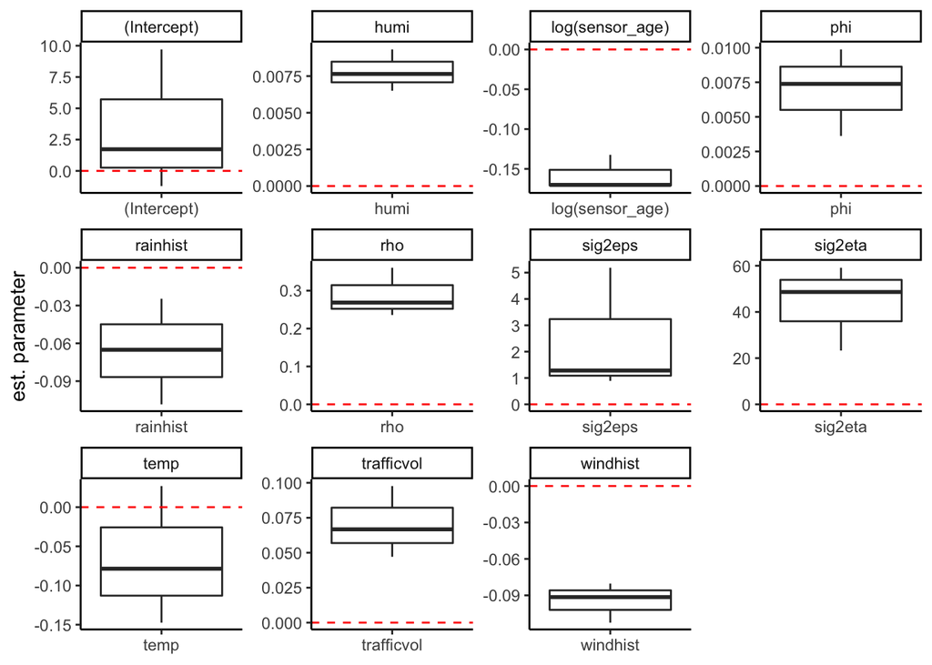

```r
plot(para.1week)
```

```r
# How to choose the knots --------------------------------------------------
```

# How to choose the knots

There are three methods how to specify the knots (1) Use a matrix of your favorite knots coordinates (2) Specify a regular grid by choosing the column and row count (3) Choose a random knots location based on the density of the position of the sensors. For more details see the master-thesis: Spatio-temporal modelling of air pollution open data (1): I don’t have my favorite locations in Munich in coordinates, so I choose randomly 20 grid points from the dataset muc_airPol_p2_grid

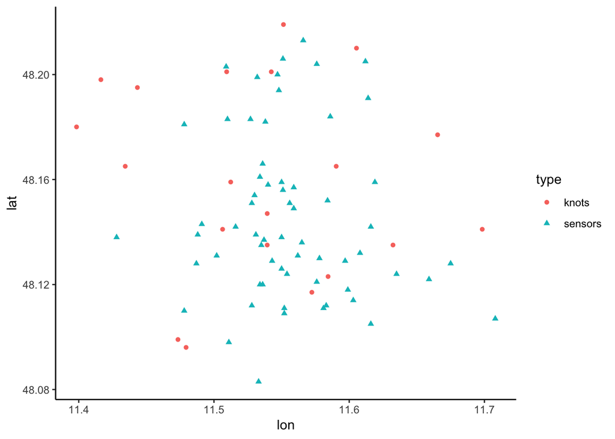

```
##
##  Output: GPP approximation models
## ---------------------------------------------------------------
##  Sampled: 5000 of 5000, 100.00%.
##  Batch Acceptance Rate (phi): 51.35%
##  Checking Parameters:
##    phi: 2.4266, rho: 0.1631, sig2eps: 0.4080, sig2eta: 1.4694
##    beta[1]: 4.3491   beta[2]: 0.0100   beta[3]: -0.0495   beta[4]: -0.0565   beta[5]: -0.0904   beta[6]: 0.0568   beta[7]: -0.1574
## ---------------------------------------------------------------
## ##
## # nBurn =  1000 . Iterations =  5000 .
## # Acceptance rate: (phi) =  51.34 %
## ##
## ##
## # Elapsed time: 3.45 Sec.
## ##
##
## # Model: GPP
```

```r
data("muc_airPol_p2_grid")
set.seed(2202)
count <- nrow(unique(muc_airPol_p2_grid[, .(lon, lat)]))
knots <- as.matrix(unique(muc_airPol_p2_grid[, .(lon, lat)])[sample(1:count, 20)])
model.gpp.selected <- fit_sp_model(data = data,
                             formula = formula,
                             model = 'GPP',
                             priors = priors.gpp,
                             cov.fnc = cov.fnc,
                             knots = knots,
                             knots_plot = TRUE,
                             training_set = training_set,
                             scale.transform = scale.transform,
                             spatial.decay = spatial.decay)
```

```r
pred.gpp.selected <- predict(model.gpp.selected, data, training_set)
```

```
##
##  Prediction: GPP models
## -------------------------------------------------
##   Sampled: 400 of 4000, 10.00%
## -------------------------------------------------
## -------------------------------------------------
##   Sampled: 800 of 4000, 20.00%
## -------------------------------------------------
## -------------------------------------------------
##   Sampled: 1200 of 4000, 30.00%
## -------------------------------------------------
## -------------------------------------------------
##   Sampled: 1600 of 4000, 40.00%
## -------------------------------------------------
## -------------------------------------------------
##   Sampled: 2000 of 4000, 50.00%
## -------------------------------------------------
## -------------------------------------------------
##   Sampled: 2400 of 4000, 60.00%
## -------------------------------------------------
## -------------------------------------------------
##   Sampled: 2800 of 4000, 70.00%
## -------------------------------------------------
## -------------------------------------------------
##   Sampled: 3200 of 4000, 80.00%
## -------------------------------------------------
## -------------------------------------------------
##   Sampled: 3600 of 4000, 90.00%
## -------------------------------------------------
## -------------------------------------------------
##   Sampled: 4000 of 4000, 100.00%
## -------------------------------------------------
## ##
## # Predicted samples and summary statistics are given.
## # nBurn =  1000 . Iterations =  5000 .
## ##
## ##
## # Elapsed time: 1.72 Sec.
## ##
```

2. I want a 5 times 4 grid, so I set knots_count = c(5,4)

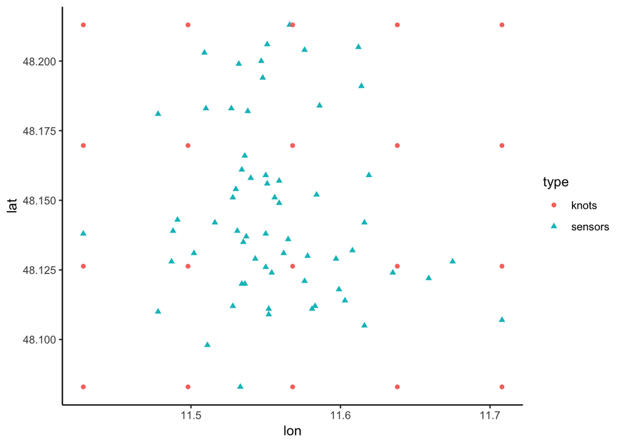

```
##
##  Output: GPP approximation models
## ---------------------------------------------------------------
##  Sampled: 5000 of 5000, 100.00%.
##  Batch Acceptance Rate (phi): 14.12%
##  Checking Parameters:
##    phi: 0.0001, rho: 0.3304, sig2eps: 0.4142, sig2eta: 268.2170
##    beta[1]: 36.2875   beta[2]: 0.0045   beta[3]: -0.0468   beta[4]: -0.0439   beta[5]: -0.0929   beta[6]: 0.0908   beta[7]: -0.1272
## ---------------------------------------------------------------
## ##
## # nBurn =  1000 . Iterations =  5000 .
## # Acceptance rate: (phi) =  14.12 %
## ##
## ##
## # Elapsed time: 3.39 Sec.
## ##
##
## # Model: GPP
```

```r
model.gpp.grid <- fit_sp_model(data = data,
                          formula = formula,
                          model = 'GPP',
                          priors = priors.gpp,
                          cov.fnc = cov.fnc,
                          knots_count = c(5,4),
                          knots_plot = TRUE,
                          training_set = training_set,
                          scale.transform = scale.transform,
                          spatial.decay = spatial.decay)
```

```r
pred.gpp.grid <- predict(model.gpp.grid, data, training_set)
```

```
##
##  Prediction: GPP models
## -------------------------------------------------
##   Sampled: 400 of 4000, 10.00%
## -------------------------------------------------
## -------------------------------------------------
##   Sampled: 800 of 4000, 20.00%
## -------------------------------------------------
## -------------------------------------------------
##   Sampled: 1200 of 4000, 30.00%
## -------------------------------------------------
## -------------------------------------------------
##   Sampled: 1600 of 4000, 40.00%
## -------------------------------------------------
## -------------------------------------------------
##   Sampled: 2000 of 4000, 50.00%
## -------------------------------------------------
## -------------------------------------------------
##   Sampled: 2400 of 4000, 60.00%
## -------------------------------------------------
## -------------------------------------------------
##   Sampled: 2800 of 4000, 70.00%
## -------------------------------------------------
## -------------------------------------------------
##   Sampled: 3200 of 4000, 80.00%
## -------------------------------------------------
## -------------------------------------------------
##   Sampled: 3600 of 4000, 90.00%
## -------------------------------------------------
## -------------------------------------------------
##   Sampled: 4000 of 4000, 100.00%
## -------------------------------------------------
## ##
## # Predicted samples and summary statistics are given.
## # nBurn =  1000 . Iterations =  5000 .
## ##
## ##
## # Elapsed time: 1.81 Sec.
## ##
```

3. I want to set 20 random knots based on the sensor density

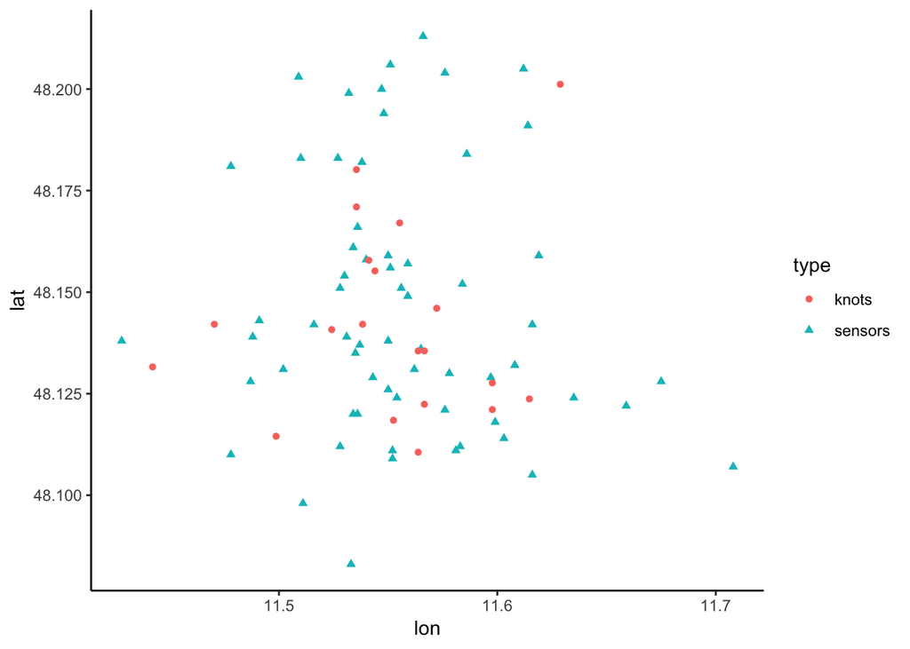

```
##
##  Output: GPP approximation models
## ---------------------------------------------------------------
##  Sampled: 5000 of 5000, 100.00%.
##  Batch Acceptance Rate (phi): 42.57%
##  Checking Parameters:
##    phi: 2.7825, rho: 0.0770, sig2eps: 0.5862, sig2eta: 0.4693
##    beta[1]: 3.6742   beta[2]: 0.0071   beta[3]: -0.0621   beta[4]: -0.0517   beta[5]: -0.0914   beta[6]: 0.0771   beta[7]: -0.0849
## ---------------------------------------------------------------
## ##
## # nBurn =  1000 . Iterations =  5000 .
## # Acceptance rate: (phi) =  42.56 %
## ##
## ##
## # Elapsed time: 3.43 Sec.
## ##
##
## # Model: GPP
```

```r
model.gpp.random <- fit_sp_model(data = data,
                          formula = formula,
                          model = 'GPP',
                          priors = priors.gpp,
                          cov.fnc = cov.fnc,
                          knots_count = 20,
                          knots_method = 'random',
                          knots_plot = TRUE,
                          knots_seed = 220292,
                          training_set = training_set,
                          scale.transform = scale.transform,
                          spatial.decay = spatial.decay)
```

```r
pred.gpp.random <- predict(model.gpp.random, data, training_set)
```

```
##
##  Prediction: GPP models
## -------------------------------------------------
##   Sampled: 400 of 4000, 10.00%
## -------------------------------------------------
## -------------------------------------------------
##   Sampled: 800 of 4000, 20.00%
## -------------------------------------------------
## -------------------------------------------------
##   Sampled: 1200 of 4000, 30.00%
## -------------------------------------------------
## -------------------------------------------------
##   Sampled: 1600 of 4000, 40.00%
## -------------------------------------------------
## -------------------------------------------------
##   Sampled: 2000 of 4000, 50.00%
## -------------------------------------------------
## -------------------------------------------------
##   Sampled: 2400 of 4000, 60.00%
## -------------------------------------------------
## -------------------------------------------------
##   Sampled: 2800 of 4000, 70.00%
## -------------------------------------------------
## -------------------------------------------------
##   Sampled: 3200 of 4000, 80.00%
## -------------------------------------------------
## -------------------------------------------------
##   Sampled: 3600 of 4000, 90.00%
## -------------------------------------------------
## -------------------------------------------------
##   Sampled: 4000 of 4000, 100.00%
## -------------------------------------------------
## ##
## # Predicted samples and summary statistics are given.
## # nBurn =  1000 . Iterations =  5000 .
## ##
## ##
## # Elapsed time: 1.76 Sec.
## ##
```

Compair the results

```r
evaluate_prediction_table(list('pred.gpp.selected' = pred.gpp.selected,
                               'pred.gpp.grid' = pred.gpp.grid,
                               'pred.gpp.random' = pred.gpp.random))
```

```
##                model RMSE  MAE  BIAS Coverage   R2
## 1: pred.gpp.selected 4.17 3.24 -0.19     0.98 0.65
## 2:     pred.gpp.grid 4.28 3.30 -0.40     0.96 0.62
## 3:   pred.gpp.random 4.06 3.13 -0.35     0.98 0.68
```